# Lennon-McCartney

Céline Kattenberg

2/10/2021

### Lennon-McCartney

The Lennon-McCartney songwriting partnership was one of the most successful musical cooperations of all time. In the early days of the Beatles, John Lennon and Paul McCartney would often collaborate on songs extensively. As teenagers, they had made an agreement that they would both be credited with all songs written by either of them, whether jointly or separately. This is why all Beatles songs written by either Lennon or McCartney are officially credited to “Lennon-McCartney”. Later on it became increasingly common for them to write songs separately.

In an interview for Playboy Magazine in 1980, Lennon said the following about his songwriting partnership with McCartney:

> [Paul] provided a lightness, an optimism, while I would always go for the sadness, the discords, the bluesy notes. There was a period when I thought I didn’t write melodies, that Paul wrote those and I just wrote straight, shouting rock ‘n’ roll. But, of course, when I think of some of my own songs—“In My Life”, or some of the early stuff, “This Boy”—I was writing melody with the best of them.

I would be curious to see whether Lennon’s characterization of the differences between his and McCartney’s songwriting styles is accurate. The spotify API provides some features by which this potential difference could be explored. For example, the *valence* and *energy* features of the AudioFeaturesObject could be useful.

### Corpus

For this course, I will compare Beatles songs written (predominantly) by Paul McCartney to those written (predominantly) by John Lennon. To this end I created two playlists on Spotify. One playlist for the McCartney songs and one for the Lennon songs. I used the following webpage: http://www.myrsten.nu/worldnet/beatlesongs.htm as a guide to determine which song was written by whom. The corpus contains 142 songs in total (70 written by Paul McCartney and 72 written by John Lennon).

### Data Exloration

First, we will load the playlists containing each artist’s songs. Then, we put them all into a single dataframe.

```r
john_songs <- get_playlist_audio_features("", "6Wxl8tFi8QruTJ8ERPFkFc")
paul_songs <- get_playlist_audio_features("", "64vy4b9yg9tcvrf0a3XvdF")

george_songs <- get_playlist_audio_features("", "4DPiVpe75MnJkwNH31CBay")
ringo_songs <- get_playlist_audio_features("", "6Zhk7J5Ptorytp5HoFXNOc")
```

```r
all_songs <-
  bind_rows(
    john_songs %>% mutate(category = "John"),
    paul_songs %>% mutate(category = "Paul"),
    #george_songs %>% mutate(category = "George"),
    #ringo_songs %>% mutate(category = "Ringo")
  )
```

Now, we can start exploring the data!

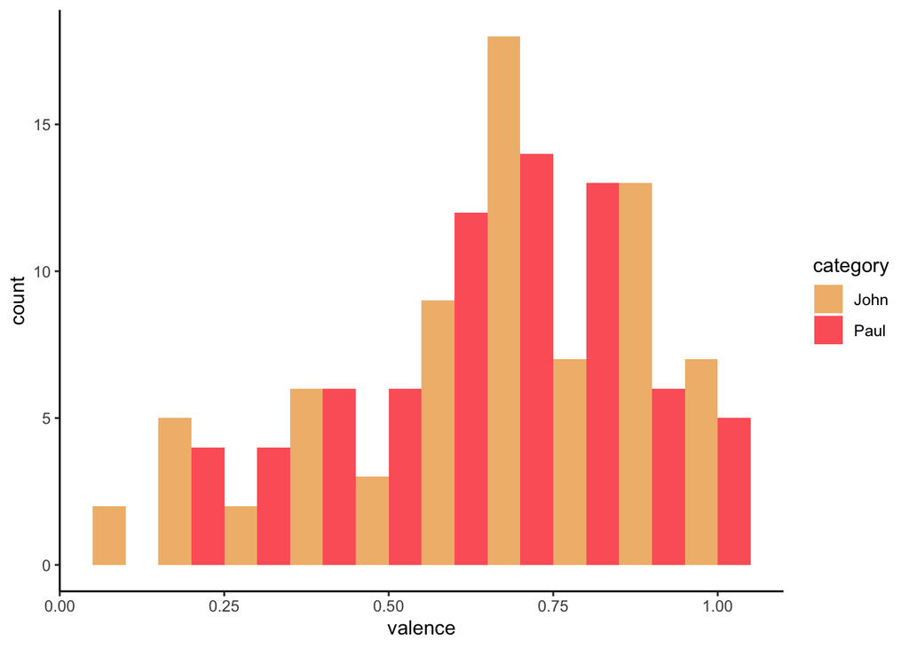

```r
ggplot(data = all_songs) +
  geom_histogram(mapping = aes(x = valence, fill = category), position = "dodge", binwidth = 0.1) +
  theme_classic() +
  scale_fill_manual(values=wes_palette(n=4, name="GrandBudapest1"))
```

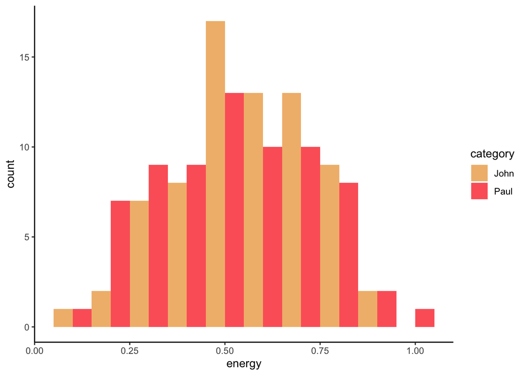

```r
ggplot(data = all_songs) +
  geom_histogram(mapping = aes(x = energy, fill = category), position = "dodge", binwidth = 0.1) +
  theme_classic()  +
  scale_fill_manual(values=wes_palette(n=4, name="GrandBudapest1"))
```

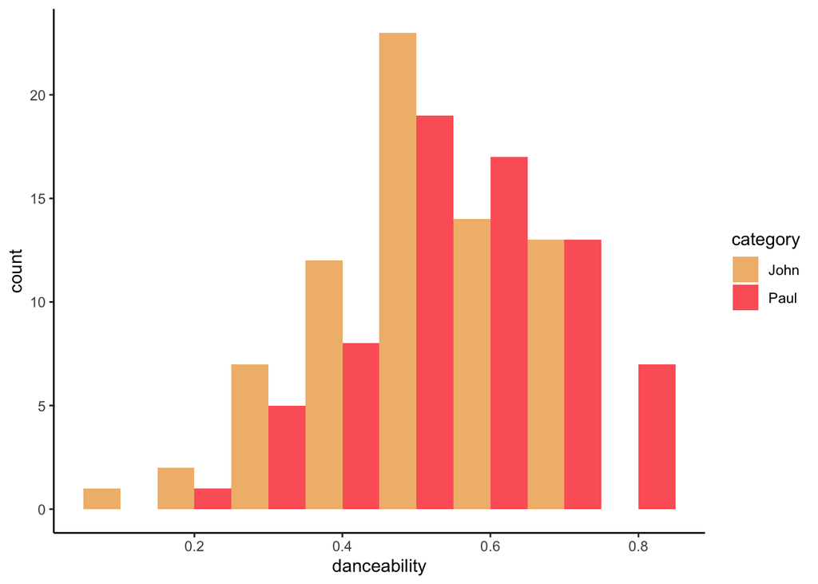

```r
ggplot(data = all_songs) +
  geom_histogram(mapping = aes(x = danceability, fill = category), position = "dodge", binwidth = 0.1) +
  theme_classic() +
  scale_fill_manual(values=wes_palette(n=4, name="GrandBudapest1"))
```

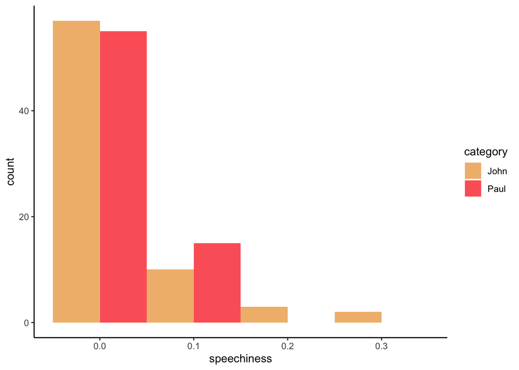

```r
ggplot(data = all_songs) +
  geom_histogram(mapping = aes(x = speechiness, fill = category), position = "dodge", binwidth = 0.1) +
  theme_classic() +
  scale_fill_manual(values=wes_palette(n=4, name="GrandBudapest1"))
```

The graphs above show that, generally speaking, John Lennon’s songs don’t have lower valence than Paul McCartney’s songs. This is surprising because it contradicts the statement John Lennon made to Playboy Magazine. However, it does appear to be the case that Paul’s songs have a higher level of danceability, according to the Spotify API. On average, John’s songs are higher in energy level. This makes sense, because John said he liked to write “shouting rock ‘n’ roll”. I also noticed that John has more “speechy” songs than Paul.

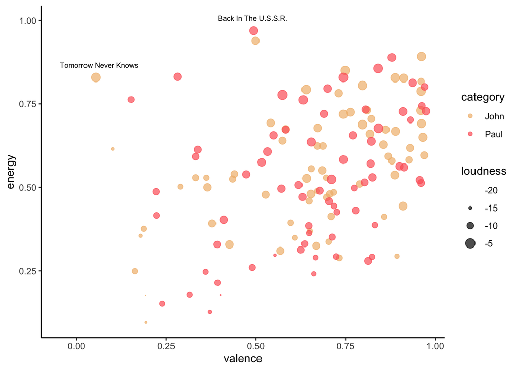

The differences between the Beatles’ songwriting styles seems to be very small, at least in terms of valence and energy.

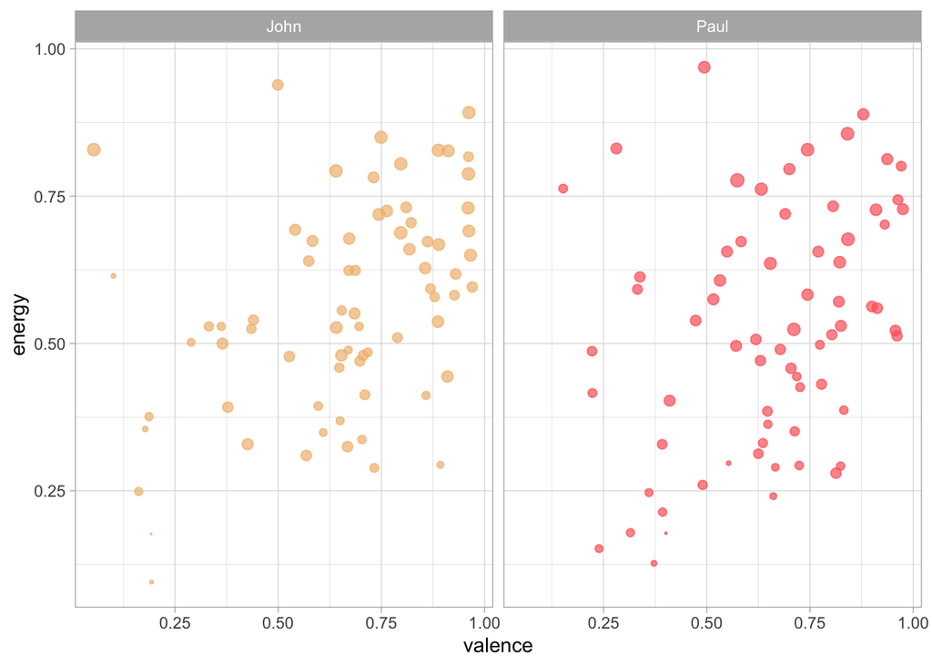

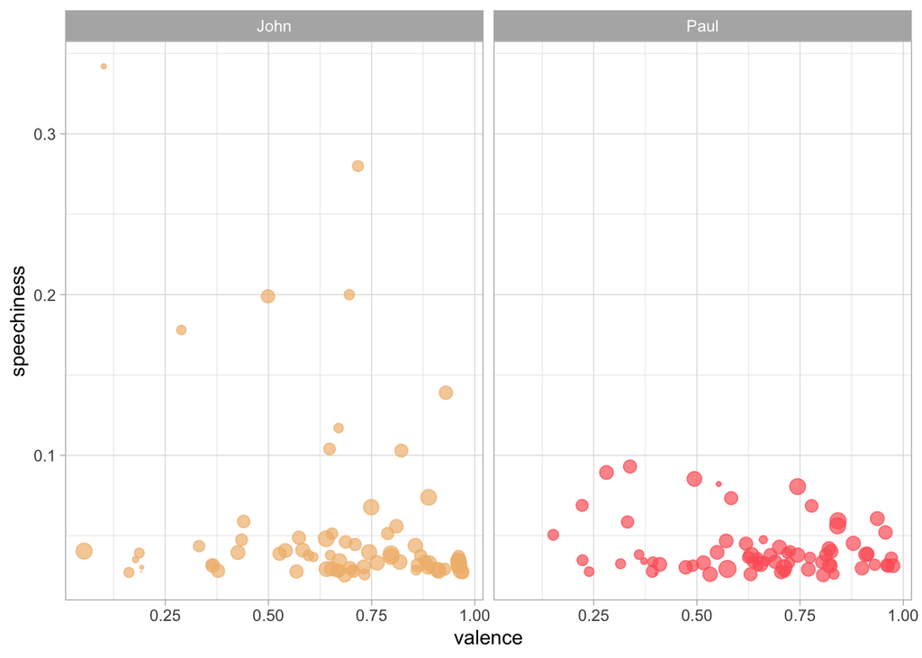